# READ_ME

Pierre Gloaguen, Laetitia Chapel, Chloé Friguet, Romain Tavenard, Guillaume Hajduch, Rodolphe Vadaine

July 2019

# About the dataset

This dataset corresponds to 6 months of AIS data of vessels steaming in the area of the Ushant traffic separation scheme (in Brittany, West of France). This is an area with one of the highest traffic density in the world, with a clear separation scheme with two navigation lanes. Different kinds of vessels are present in the area, from cargos and tankers with high velocity and straight routes to sailing boats or fishing vessels with low speed and different sailing directions. As such, the area is highly monitored to avoid collision or grounding, and a better analysis and understanding of the different ship behaviors is of prime importance.

The whole trajectory data set consists in 18,603 trajectories, gathering overall more than 7 millions GPS observations. Only trajectories having more than 30 points were kept, time lag between two consecutive observations ranges between 5 seconds and 15 hours, with 95% of time lags below 3 minutes.

# Acknowledgements

Authors would like to thank CLS (Collecte Localisation Satellites) and Erwan Guegueniat for providing the raw data that allowed building this dataset. This work has been supported by DGA through the ANR/Astrid SESAME project (ref: ANR-16-ASTR-0026).

# Content of the directory

This directory contains data presented in the article *“Scalable clustering of {segmented} trajectories within a continuous time framework: application to maritime traffic data”* by Gloaguen et al.

The data directory contains 18603 files, each of them being a trajectory.

Each file has the following structure (with a varying number of rows):

| x | y | vx | vy | t |
| --- | --- | --- | --- | --- |
| -5.95 | 48.41 | 5.28 | 13.07 | 0 |
| -5.94 | 48.41 | 5.24 | 12.98 | 63 |
| -5.94 | 48.41 | 5.28 | 13.07 | 85 |
| -5.94 | 48.41 | 5.24 | 12.98 | 114 |
| -5.94 | 48.42 | 5.24 | 12.98 | 180 |
| -5.94 | 48.42 | 5.24 | 12.98 | 272 |

where:

- `x` is the longitude (in degrees)
- `y` is the latitude (in degrees)
- `vx` is the x-velocity (in knots) **given in the AIS message** (not computed from positions and time)
- `vy` is the y-velocity (in knots) **given in the AIS message** (not computed from positions and time)
- `t` the time since the beginning of the trajectory (in seconds).

# Reading data in R

In R, it’s simple:

```r
my_data <- read.table("data/traj_1.txt", sep = ";", header = T)
```

The data is therefore is a `data.frame` object, and can be manipulated in the usual way.

```r
class(my_data)
```

```
## [1] "data.frame"
```

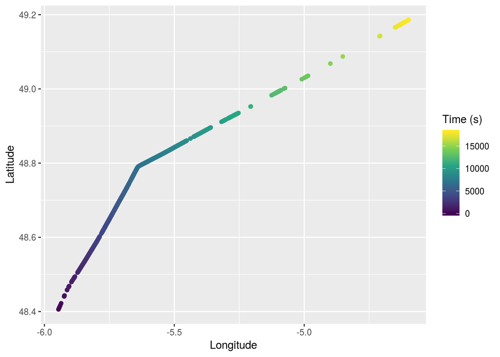

```r
library(ggplot2) # graphics library
ggplot(data = my_data, mapping = aes(x = x, y = y, color = t)) +
  geom_point() +
  labs(x = "Longitude", y = "Latitude", color = "Time (s)") +
  scale_color_viridis_c() # Palette for color blind people
```

# Reading data in python

To import the data in python, the following code does the job:

```python
import numpy as np
my_data = np.loadtxt("data/traj_1.txt", delimiter = ";", skiprows = 1)
my_data.shape
```

```
(768, 5)
```